# Final Project

Diana Gao

2024-12-10

[figure not shown]

# Setup

### Load Packages

```r
library(tidyverse)
library(here)
library(janitor)
library(reshape2) # for working with matrices
library(phytools) # for working with phylo data
library(patchwork)
```

### Load data

I will use bird morphological measurements from AVONET, combined with my own general info about honeycreepers. In addition, I will use the most-resolved currently published honeycreeper phylogeny from [Lerner et al. 2011](https://doi.org/10.1016/j.cub.2011.09.039), digitized by Dr. Matzke as part of [his paper](https://doi-org.eres.library.manoa.hawaii.edu/10.1093/sysbio/syu056), plotted below for your viewing pleasure :)

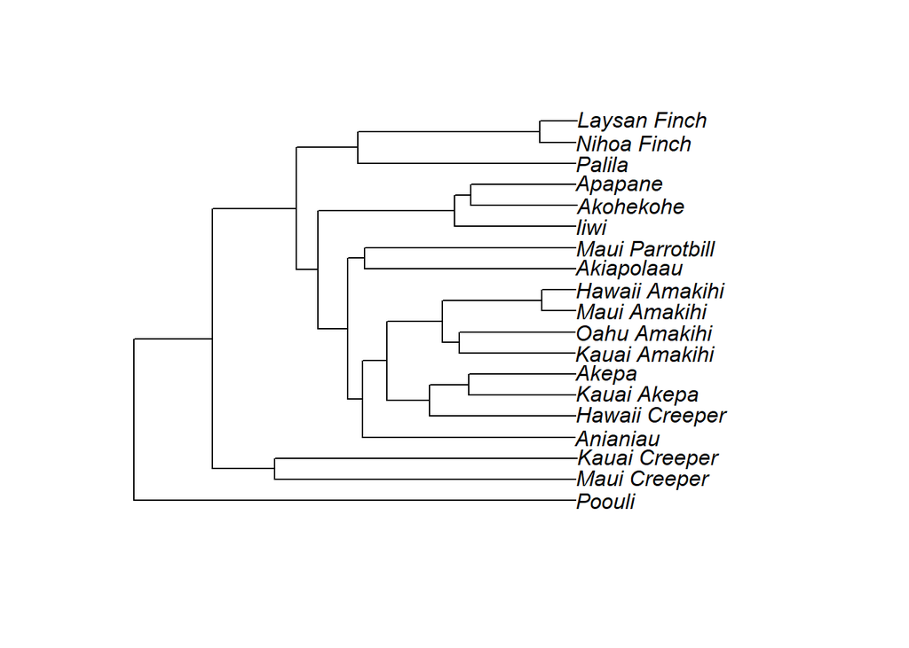

```r
data <- read_csv(here("data", "AVONET_Raw_Data.csv")) # avonet data
names <- read_csv(here("data", "Honeycreeper_info.csv")) # gathered honeycreeper info

tree_name <- file.path(here("data", "Lerner_etal_2011_CurrBio_honeycreepers_mod.newick"))
tree <- read.newick(tree_name)
plot(tree) # test that the tree read in correctly
```

### Functions

I’m going to make my own function to normalize and scale my data so the math that I am doing is transparent :)

```r
standardize <- function(x){
  z <- (x - mean(x)) / sd(x)
  return( z)
}
```

# Cleaning

For this project, I will be using data from AVONET, an online database of bird data. In particular, I will be selecting out the HI honeycreepers within this dataset. There were many complications with this process because of multiple species having alternative scientific names as well as the phylogenetic data having a mix of the common or ’ōlelo names. Sigh.

### Morphological data

```r
names_clean <- names %>%
  clean_names()
morpho <- data %>%
  select(Avibase.ID:Publication) %>% # for some reason imported with a bunch of extra empty cols?
  clean_names() %>% # clean names lol
  #there are species with alternate names, so I want to make sure that if they are named under this name they are still captured within the dataset
  mutate(across(species1_bird_life:species3_bird_tree,
                ~ ifelse(. == "Hemignathus munroi", "Hemignathus wilsoni", .))) %>% #change alt sci names (munroi) into their primary names as listed in names_clean (wilsoni), . means if false keep value in cell currently
  mutate(across(species1_bird_life:species3_bird_tree,
                ~ ifelse(. == "Hemignathus flavus", "Chlorodrepanis flava", .))) %>%
  mutate(across(species1_bird_life:species3_bird_tree,
                ~ ifelse(. == "Hemignathus kauaiensis", "Chlorodrepanis stejnegeri", .))) %>%
  mutate(across(species1_bird_life:species3_bird_tree,
                ~ ifelse(. == "Loxops coccineus coccineus", "Loxops coccineus", .))) %>%
  mutate(across(species1_bird_life:species3_bird_tree,
                ~ ifelse(. == "Oreomystis mana", "Manucerthia mana", .))) %>%
  mutate(across(species1_bird_life:species3_bird_tree,
                ~ ifelse(. == "Loxops mana", "Manucerthia mana", .))) %>%
  mutate(across(species1_bird_life:species3_bird_tree,
                ~ ifelse(. == "Hemignathus virens", "Chlorodrepanis virens", .))) %>%
  filter(species1_bird_life != "Himatione fraithii") %>% # this one particular sp seems to be mis-named as Himatione sanguinea in the birdtree dataset but im not sure? so I will remove these rows instead
  rename("sci_name" = species1_bird_life) %>% # make col names match for join
  inner_join(names_clean, by = "sci_name") %>%
  select(avibase_id, sci_name, hi_name, common_name, diet, detailed_diet, source:age, beak_length_culmen:tail_length) %>%
  mutate(common_name = coalesce(common_name, hi_name)) %>% # coalesce (frm dplyr) is good for replacing NAs with values from other vectors. if there is a missing common name, use the name from the hi_name column
  mutate(common_name = str_replace_all(common_name, "`", "")) %>% # get rid of tone markings so it can match the names from the phylo
  mutate(common_name = str_replace_all(common_name, "ō", "o")) %>%
  mutate(common_name = str_replace_all(common_name, "ā", "a"))
```

So after all of that, we can finally have a nice table with all of our honeycreeper info and specimens’ measurements from AVONET. The dietary info is taken from the HI DLNR website. Note that measurements are in mm (or g for body mass) Here it is:

```r
morpho
```

| avibase_id | sci_name | hi_name | common_name | diet | detailed_diet | source | specimen_number | sex | age | beak_length_culmen | beak_length_nares | beak_width | beak_depth | tarsus_length | wing_length | kipps_distance | secondary1 | hand_wing_index | tail_length |
| --- | --- | --- | --- | --- | --- | --- | --- | --- | --- | --- | --- | --- | --- | --- | --- | --- | --- | --- | --- |
| AVIBASE-0A603DFD | Chlorodrepanis flava | O`ahu `amakihi | Oahu amakihi | Generalist | "O`ahu `amakihi are generalized foragers that take arthropods from a variety of trees and substrates. The species often gleans arthropods from leaves and twigs, less frequently from larger branches an… | YPM | 11828 | M | 0 | 18.5 | 12.3 | 3.6 | 4.0 | 21.5 | 65.0 | 15.1 | 49.9 | 23.2 | 47.0 |
| AVIBASE-0A603DFD | Chlorodrepanis flava | O`ahu `amakihi | Oahu amakihi | Generalist | "O`ahu `amakihi are generalized foragers that take arthropods from a variety of trees and substrates. The species often gleans arthropods from leaves and twigs, less frequently from larger branches an… | NHMUK | 1925.2.16.64 | F | 0 | 16.2 | 10.6 | 3.2 | 4.0 | 19.7 | 58.0 | 15.4 | 42.6 | 26.6 | 41.0 |
| AVIBASE-0A603DFD | Chlorodrepanis flava | O`ahu `amakihi | Oahu amakihi | Generalist | "O`ahu `amakihi are generalized foragers that take arthropods from a variety of trees and substrates. The species often gleans arthropods from leaves and twigs, less frequently from larger branches an… | NHMUK | 95.7.20.133 | F | 0 | 16.3 | 11.8 | 3.7 | 3.9 | 19.1 | 61.0 | 15.6 | 45.5 | 25.6 | 40.0 |
| AVIBASE-0A603DFD | Chlorodrepanis flava | O`ahu `amakihi | Oahu amakihi | Generalist | "O`ahu `amakihi are generalized foragers that take arthropods from a variety of trees and substrates. The species often gleans arthropods from leaves and twigs, less frequently from larger branches an… | NHMUK | 95.7.20.135 | M | 0 | 17.1 | 12.5 | 3.5 | 3.9 | 21.6 | 64.0 | 21.0 | 43.0 | 32.8 | 42.0 |
| AVIBASE-5305B509 | Chlorodrepanis stejnegeri | Kaua`i `amakihi | Kauai amakihi | Generalist | "They glean arthropods from branches and trunks as well as leaves, often hanging upside down to examine the underside of branches. Also explores bark crevices for food items, pierces the bases of `ōhi… | NHMUK | 1925.2.16.37 | M | 0 | 21.3 | 13.5 | 3.9 | 4.8 | 21.5 | 67.0 | 19.7 | 47.3 | 29.4 | 40.0 |
| AVIBASE-5305B509 | Chlorodrepanis stejnegeri | Kaua`i `amakihi | Kauai amakihi | Generalist | "They glean arthropods from branches and trunks as well as leaves, often hanging upside down to examine the underside of branches. Also explores bark crevices for food items, pierces the bases of `ōhi… | NHMUK | 1925.2.16.45 | F | 0 | 19.8 | 13.2 | 3.9 | 5.3 | 21.9 | 62.0 | 13.9 | 48.1 | 22.4 | 38.0 |
| AVIBASE-5305B509 | Chlorodrepanis stejnegeri | Kaua`i `amakihi | Kauai amakihi | Generalist | "They glean arthropods from branches and trunks as well as leaves, often hanging upside down to examine the underside of branches. Also explores bark crevices for food items, pierces the bases of `ōhi… | ZMB | 2000/39478 | U | 0 | 22.8 | 15.5 | 3.7 | 5.2 | 21.4 | 68.0 | 16.8 | 51.2 | 24.7 | 40.0 |
| AVIBASE-5305B509 | Chlorodrepanis stejnegeri | Kaua`i `amakihi | Kauai amakihi | Generalist | "They glean arthropods from branches and trunks as well as leaves, often hanging upside down to examine the underside of branches. Also explores bark crevices for food items, pierces the bases of `ōhi… | ZMB | 2000/39479 | U | 0 | 21.2 | 14.2 | 4.0 | 5.2 | 22.1 | 67.0 | 16.1 | 50.9 | 24.0 | 41.0 |
| AVIBASE-5305B509 | Chlorodrepanis stejnegeri | Kaua`i `amakihi | Kauai amakihi | Generalist | "They glean arthropods from branches and trunks as well as leaves, often hanging upside down to examine the underside of branches. Also explores bark crevices for food items, pierces the bases of `ōhi… | NHMUK | 97.10.28.53 | F | 0 | 19.9 | 14.1 | 3.8 | 5.3 | 21.7 | 67.0 | 17.0 | 50.0 | 25.4 | 43.0 |
| AVIBASE-5305B509 | Chlorodrepanis stejnegeri | Kaua`i `amakihi | Kauai amakihi | Generalist | "They glean arthropods from branches and trunks as well as leaves, often hanging upside down to examine the underside of branches. Also explores bark crevices for food items, pierces the bases of `ōhi… | NHMUK | 97.10.28.54 | M | 0 | 19.8 | 14.1 | 3.8 | 5.5 | 21.9 | 63.0 | 17.5 | 45.6 | 27.8 | 42.0 |

[output cut: 66 more lines]

# Analysis

My end goal for this analysis is to create scaled and normalilzed regressions of the pairwise phylogenetic and morphometric distances between each species in order to see if there is some relationship between the two which differs from the null. If I had more time, I would definetly add more statistical rigor but for now I am just trying to get things working.

## Matrix making

But before comaring the pairwise distances, we first have to generate them. First, I will average all the specimens within a species, then I will calculate pairwise distances.

Luckily there is a function (stats::dist()) which does this. As well as (phytools::cophenetic.phylo()), which finds distances based on branch lengths from phylogenetic data. Once I make the matrices, then I melt them into a dataframe, with the important columns being the pair of names and the other being the distance between the pair. Whew!

Note that the final data will have duplicates in the form of reciprocated pairs (eg. akohekohe, anianiau and anianiau, akohekohe). Probably best practice would be to cut these out but I’m not actually doing much in terms of statistical testing so it doesn’t matter too much for me :P One thing I did do is to make sure to cut out pairwise distnaces between the same species as they are inherently going to be 0. I didn’t want these 0s to skew the z-scoring and they are not informative data.

### Morphometric Data

Again, so much cleaning so that the phylogenetic and morphometric data can match. Also, I really struggled to make the matrix keep the species names for some reason T_T

#### Beak Length

This measurement is specifically for beak length to the culmen (see fig. 1). There was also beak length to the nares, but I arbitrarily chose to do this one.

```r
#first cut up the table a bit
beak_length <- morpho %>%
  mutate(common_name = str_replace_all(common_name, " ", "_")) %>%
  mutate(common_name = str_replace_all(common_name, "Lesser_Amakihi", "Anianiau")) %>% # the phylo used diff names for these T_T
  mutate(common_name = str_replace_all(common_name, "Hawaii_akepa", "Akepa")) %>%
  mutate(common_name = str_replace_all(common_name, "Crested_honeycreeper", "Akohekohe")) %>%
  filter(common_name != "Akepa") %>% # akepa has no data so remove it from the matrix
  select(common_name, beak_length_culmen) %>%
  group_by(common_name) %>%
  summarise(mean_length_culmen = mean(beak_length_culmen))

# now make the pairwise distances
length_matrix=dist(beak_length)
length_matrix=as.matrix(length_matrix, labels=TRUE)
colnames(length_matrix) <- rownames(length_matrix) <- beak_length[['common_name']] #this line makes sure that the matrix retains the names

cleaned_length_dist <- length_matrix %>%
  melt() %>%
  filter(Var1 != Var2) %>% # remove the comparisons btween the same sp (inherently will be 0), so they dont skew scaling
  mutate(Var1 = str_to_lower(Var1)) %>% # make everything lowercase to make the matching easier
  mutate(Var2 = str_to_lower(Var2)) %>%
  mutate(pair = paste(Var1, ",", Var2))
head(cleaned_length_dist) # to check that this all went smoothly
```

|  | Var1 | Var2 | value | pair |
| --- | --- | --- | --- | --- |
| 1 | akohekohe | akiapolaau | 1.025305 | akohekohe , akiapolaau |
| 2 | anianiau | akiapolaau | 10.641957 | anianiau , akiapolaau |
| 3 | apapane | akiapolaau | 4.242641 | apapane , akiapolaau |
| 4 | hawaii_amakihi | akiapolaau | 7.872460 | hawaii_amakihi , akiapolaau |
| 5 | hawaii_creeper | akiapolaau | 10.217693 | hawaii_creeper , akiapolaau |
| 6 | iiwi | akiapolaau | 8.456997 | iiwi , akiapolaau |

Amazing :) Now do the same thing with beak width and depth!

#### Beak Width

```r
##### first cut up the table a bit
beak_width <- morpho %>%
  mutate(common_name = str_replace_all(common_name, " ", "_")) %>%
  mutate(common_name = str_replace_all(common_name, "Lesser_Amakihi", "Anianiau")) %>% # the phylo used diff names for these T_T
  mutate(common_name = str_replace_all(common_name, "Hawaii_akepa", "Akepa")) %>%
  mutate(common_name = str_replace_all(common_name, "Crested_honeycreeper", "Akohekohe")) %>%
  filter(common_name != "Akepa") %>% # akepa has no data so remove it from the matrix
  select(common_name, beak_width) %>%
  group_by(common_name) %>%
  summarise(mean_width = mean(beak_width))

# now make the pairwise distances
width_matrix=dist(beak_width)
width_matrix=as.matrix(width_matrix, labels=TRUE)
colnames(width_matrix) <- rownames(width_matrix) <- beak_width[['common_name']] #this is the only line

cleaned_width_dist <- width_matrix %>%
  melt() %>%
  filter(Var1 != Var2) %>%
  mutate(Var1 = str_to_lower(Var1)) %>% # make everything lowercase to make the matching easier
  mutate(Var2 = str_to_lower(Var2)) %>%
  mutate(pair = paste(Var1, ",", Var2))
```

#### Beak Depth

```r
##### first cut up the table a bit
beak_depth <- morpho %>%
  mutate(common_name = str_replace_all(common_name, " ", "_")) %>%
  mutate(common_name = str_replace_all(common_name, "Lesser_Amakihi", "Anianiau")) %>% # the phylo used diff names for these T_T
  mutate(common_name = str_replace_all(common_name, "Hawaii_akepa", "Akepa")) %>%
  mutate(common_name = str_replace_all(common_name, "Crested_honeycreeper", "Akohekohe")) %>%
  filter(common_name != "Akepa") %>% # akepa has no data so remove it from the matrix,
  select(common_name, beak_depth) %>%
  group_by(common_name) %>%
  summarise(mean_depth = mean(beak_depth))

# now make the pairwise distances
depth_matrix=dist(beak_depth)
depth_matrix=as.matrix(depth_matrix, labels=TRUE)
colnames(depth_matrix) <- rownames(depth_matrix) <- beak_depth[['common_name']] #this is the only line

cleaned_depth_dist <- depth_matrix %>%
  melt() %>%
  filter(Var1 != Var2) %>%
  mutate(Var1 = str_to_lower(Var1)) %>% # make everything lowercase to make the matching easier
  mutate(Var2 = str_to_lower(Var2)) %>%
  mutate(pair = paste(Var1, ",", Var2))
```

### Phylogenetic data

Now to generate the pairwise phylogenetic distances :)

```r
phylo_dist <- cophenetic.phylo(tree) # make pairwise matrix of phylogenetic distances

cleaned_phylo_dist <- phylo_dist %>%
  melt() %>% #turn matrix into a dataframe
  mutate(Var1 = as.character(Var1)) %>% # these were factors, turn them into characters bc I don't need the factor value and so I can work with it easier
  mutate(Var2 = as.character(Var2)) %>%
  filter(Var1 != Var2) %>%
  filter(Var1 != "Akepa") %>% # no morpho data for Akepa/Hawaii Akepa, remove
  filter(Var2 != "Akepa") %>%
  filter(Var1 != "Maui_Amakihi") %>% # no morpho data for maui amakihi, remove
  filter(Var2 != "Maui_Amakihi") %>%
  mutate(Var1 = str_to_lower(Var1)) %>% # make everything lowercase to make the matching easier
  mutate(Var2 = str_to_lower(Var2)) %>%
  mutate(pair = paste(Var1, ",", Var2))
```

### Scaling

Now to perform Z-score normalization on all of this data! Then, I will make sure that I only get absolute distances, and join the phylogenetic distance to all of the morphological distances.

```r
scaled_phylo_dist <- cleaned_phylo_dist %>%
  mutate(scaled_p_dist = abs(standardize(value))) # absolute the values since I don't care about distance, I only care about size of effect.


scaled_length_dist <- cleaned_length_dist %>%
  mutate(scaled_dist = abs(standardize(value))) %>%
  left_join(scaled_phylo_dist, by = join_by(pair)) %>%
  select(pair, scaled_dist, scaled_p_dist)

scaled_width_dist <- cleaned_width_dist %>%
  mutate(scaled_dist = abs(standardize(value))) %>%
  left_join(scaled_phylo_dist, by = join_by(pair)) %>%
  select(pair, scaled_dist, scaled_p_dist)

scaled_depth_dist <- cleaned_depth_dist %>%
   mutate(scaled_dist = abs(standardize(value))) %>%
  left_join(scaled_phylo_dist, by = join_by(pair)) %>%
  select(pair, scaled_dist, scaled_p_dist)
```

#### All morpho

This is not the right way to do this but just for fun: let’s make a version of these distance dataframes that averages all the morphology in one :)

```r
scaled_morpho_dist <- scaled_length_dist %>%
  left_join(scaled_width_dist, by = join_by(pair)) %>%
  left_join(scaled_depth_dist, by = join_by(pair)) %>%
  select(pair, scaled_dist, scaled_dist.x, scaled_dist.y, scaled_p_dist) %>%
  mutate(avg_morpho_dist = rowMeans(select(.,starts_with("scaled_dist")))) %>%
  select(pair, avg_morpho_dist, scaled_p_dist)
```

## Plotting

Matching the phylo and morpho datasets was quite frustrating, not only did the phylogeny use an inconsistent mix of common and ’ōlelo names, the capitalization was inconsistent and not all species were represented in both datasets. Leading to one of my biggest time sinks, figuring out why all the pairwise distance dataframes were different lengths. T_T

But now that we cleaned that up so diligently above, lets move on to plotting!

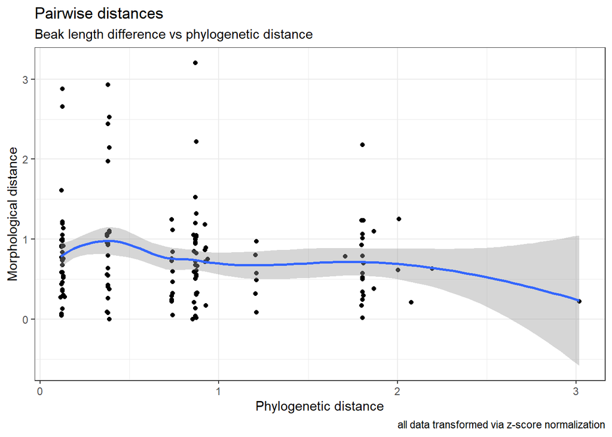

```r
sdL <- sd(scaled_length_dist$scaled_dist)
p1 <- ggplot(scaled_length_dist, aes(x = scaled_p_dist, y = scaled_dist)) +
  geom_point() +
  geom_smooth() +
  labs(title = "Pairwise distances",
       subtitle = "Beak length difference vs phylogenetic distance",
       caption = "all data transformed via z-score normalization",
       x = "Phylogenetic distance",
       y = "Morphological distance"
       ) +
  theme_bw()
plot(p1)
```

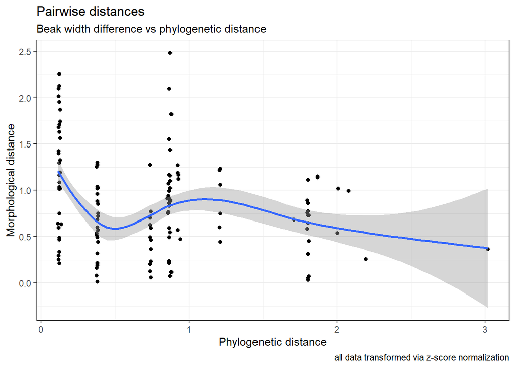

```r
p2 <- ggplot(scaled_width_dist, aes(x = scaled_p_dist, y = scaled_dist)) +
  geom_point() +
  geom_smooth() +
  labs(title = "Pairwise distances",
       subtitle = "Beak width difference vs phylogenetic distance",
       caption = "all data transformed via z-score normalization",
       x = "Phylogenetic distance",
       y = "Morphological distance"
       ) +
  theme_bw()
plot(p2)
```

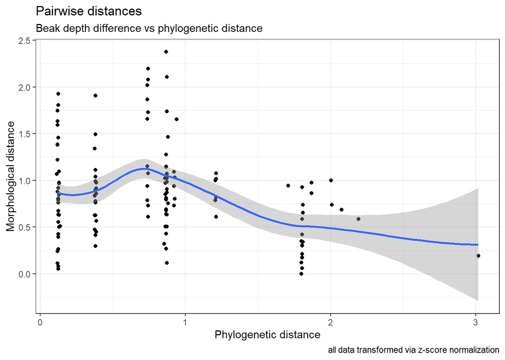

```r
p3 <- ggplot(scaled_depth_dist, aes(x = scaled_p_dist, y = scaled_dist)) +
  geom_point() +
  geom_smooth() +
  labs(title = "Pairwise distances",
       subtitle = "Beak depth difference vs phylogenetic distance",
       caption = "all data transformed via z-score normalization",
       x = "Phylogenetic distance",
       y = "Morphological distance"
       ) +
  theme_bw()
plot(p3)
```

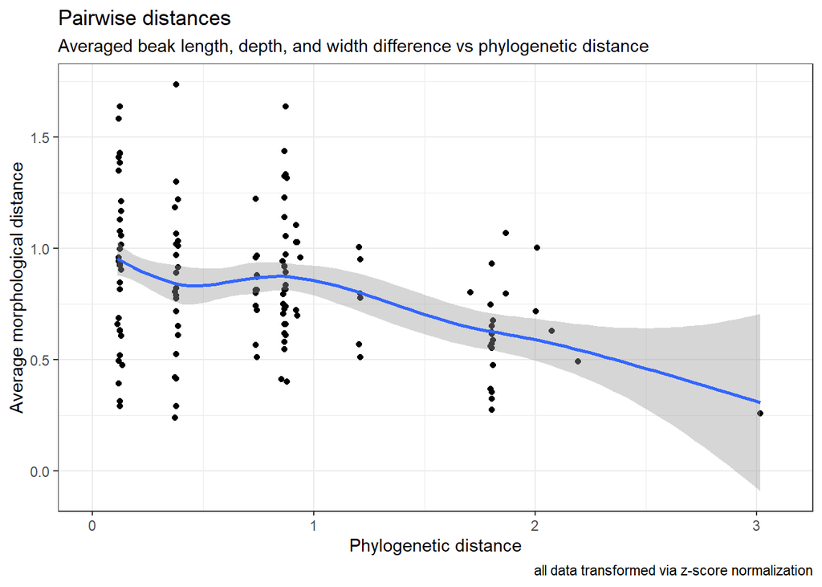

```r
p4 <- ggplot(scaled_morpho_dist, aes(x = scaled_p_dist, y = avg_morpho_dist)) +
  geom_point() +
  geom_smooth() +
  xlim(0, 3.1) +
  labs(title = "Pairwise distances",
       subtitle = "Averaged beak length, depth, and width difference vs phylogenetic distance",
       caption = "all data transformed via z-score normalization",
       x = "Phylogenetic distance",
       y = "Average morphological distance"
       ) +
  theme_bw()
plot(p4)
```

## Discussion

### Null model of trait evolution

I was really hoping to be able to plot a sort of simulated null model of trait evolution to compare the data to. Couldn’t figure it out, but I did find some code to generate this data:

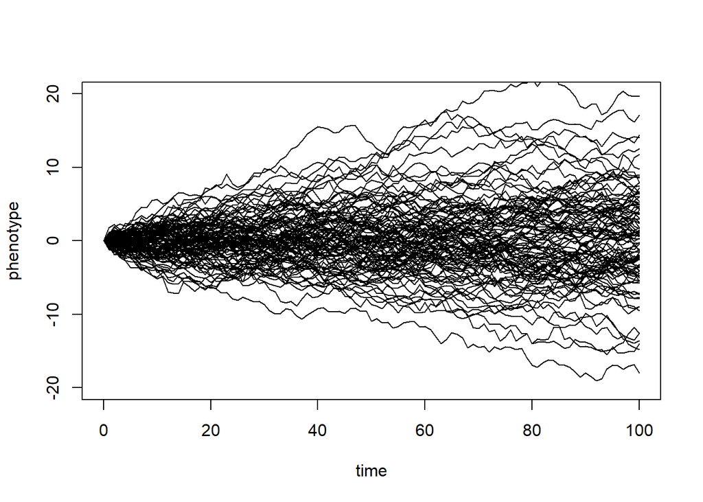

```r
t <- 0:100  # time
sig2 <- 0.37577955
nsim <- 100
X <- matrix(rnorm(n = nsim * (length(t) - 1), sd = sqrt(sig2)), nsim, length(t) -
    1)
X <- cbind(rep(0, nsim), t(apply(X, 1, cumsum)))
plot(t, X[1, ], xlab = "time", ylab = "phenotype", ylim = c(-20, 20), type = "l")
apply(X[2:nsim, ], 1, function(x, t) lines(t, x), t = t)
```

**Note that I directly copy+pasted this from a [phytools exercise](http://phytools.org/eqg/Exercise_4.1/)**

This null model is based on Brownian motion, a common null model for trait evolution:  
z(t)∼N(z(0),σ<sup>2</sup>t)  
where z is a trait value at time (t). N indicates it will follow a normal distribution, and σ<sup>2</sup> is variance.

From what I can understand of brownian motion, if I were to plot the absolute of these simulated results on a my pairwise distance graphs, it would look like an area,starting at 0,0 and increasing in morphological distance as phylogenetic distance increases.

### Any findings?

If speciation happens most when species find new, unoccupied niche space and then adapt to it (ecological release), it would show up on my above graphs as a generically negative correlation, with smaller phylogenetic distance yielding high morphological distance, and higher phylogenetic distance yielding possibly lower morphological distance (with greater variance).  
It doesn’t seem like my results were consistent with a null model of evolution. The results are muddled, with seemingly little effect of phylogenetic distance on morphological distance. Perhaps this is caused by the influence of both ecological release and genetic drift (biological theory behind null model). This all would need to be verified with statistical tests if I were to do this for realsies though. In terms of improving my current results, I have two ideas:

1. I think I just need more resolution. So more data points. Adding species (especially extinct ones) to the phylogeny and morphology datasets would probably help tremendously.
2. Making a more comprehensive measure of beak shape would be nice. Perhaps making a single measure that takes into account the beak length to the culmen, depth, width, and **curvature** of **both the upper and lower beak** would be a better approach.